### Best Model:

```r
# Check how many observed counts fall within the model's expected 95% range
inside <- function(low, high){
  mean(all_octos_wo_davis$Tally_Targets >= low & all_octos_wo_davis$Tally_Targets <= high)
}

theta <- sigma(mm_nb2_habitat2)
mu <- fitted(mm_nb2_habitat2)
c(mm_nb2_habitat2 = inside(qnbinom(0.025, mu = mu, size = theta),
                           qnbinom(0.975, mu = mu, size = theta)))
```

```
## mm_nb2_habitat2
##       0.9525547
```

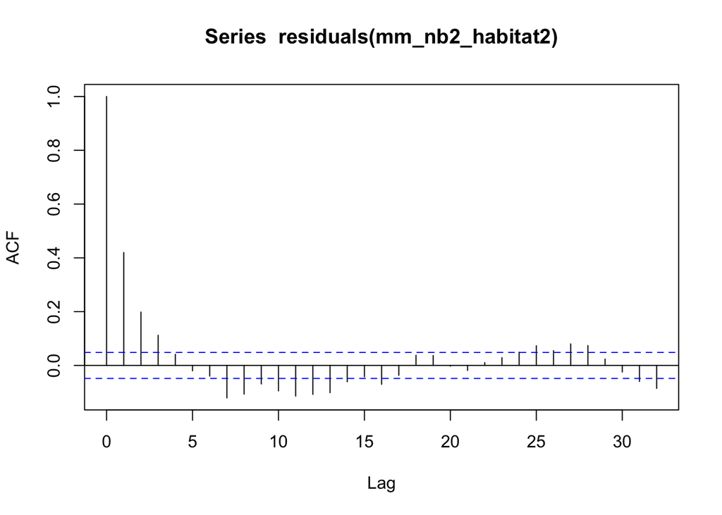

```r
# 95% of observed counts fall within model's 95% range

# Plot residuals from best model
acf(residuals(mm_nb2_habitat2))
```

```r
# Spike at lag 0, followed by tail off pattern, I think this indicates that data is stationary between years?

# Get summary of best model
summary(mm_nb2_habitat2)
```

```
##  Family: nbinom2  ( log )
## Formula:          Tally_Targets ~ SampleYear * Habitat + (1 | SiteID/StationID)
## Data: all_octos_wo_davis
##
##       AIC       BIC    logLik -2*log(L)  df.resid
##   15273.3   15592.2   -7577.6   15155.3      1585
##
## Random effects:
##
## Conditional model:
##  Groups           Name        Variance Std.Dev.
##  StationID:SiteID (Intercept) 0.1055   0.3249
##  SiteID           (Intercept) 0.6201   0.7875
## Number of obs: 1644, groups:  StationID:SiteID, 119; SiteID, 31
##
## Dispersion parameter for nbinom2 family (): 10.5
##
## Conditional model:
##                            Estimate Std. Error z value Pr(>|z|)
## (Intercept)                4.893976   0.290847  16.827  < 2e-16 ***
## SampleYear2013            -0.164285   0.086569  -1.898 0.057731 .
## SampleYear2014            -0.203240   0.084087  -2.417 0.015648 *
## SampleYear2015            -0.117589   0.083930  -1.401 0.161203
## SampleYear2016            -0.111100   0.083889  -1.324 0.185382
## SampleYear2017            -0.070717   0.086033  -0.822 0.411092
## SampleYear2018            -0.355168   0.084490  -4.204 2.63e-05 ***
## SampleYear2019            -0.034159   0.083948  -0.407 0.684075
## SampleYear2020             0.046447   0.084012   0.553 0.580359
## SampleYear2021             0.036809   0.083968   0.438 0.661118
## SampleYear2022             0.029852   0.084156   0.355 0.722794
## SampleYear2023            -0.179423   0.084205  -2.131 0.033106 *
## SampleYear2024            -0.465359   0.084689  -5.495 3.91e-08 ***
## SampleYear2025            -0.578547   0.078861  -7.336 2.20e-13 ***
## HabitatOS                 -0.496073   0.426105  -1.164 0.244341
## HabitatP                  -1.181635   0.384191  -3.076 0.002100 **
## HabitatPIN                -1.339888   0.469535  -2.854 0.004322 **
## SampleYear2013:HabitatOS   0.077203   0.129010   0.598 0.549556
## SampleYear2014:HabitatOS  -0.003256   0.125243  -0.026 0.979258
## SampleYear2015:HabitatOS  -0.023225   0.125112  -0.186 0.852735
## SampleYear2016:HabitatOS  -0.105644   0.125211  -0.844 0.398821
```

[output cut: 22 more lines]

```
## SampleYear2013:HabitatPIN  0.039837   0.143435   0.278 0.781216
## SampleYear2014:HabitatPIN -0.025259   0.142894  -0.177 0.859693
## SampleYear2015:HabitatPIN -0.152323   0.142757  -1.067 0.285970
## SampleYear2016:HabitatPIN -0.215491   0.142699  -1.510 0.131015
## SampleYear2017:HabitatPIN -0.272857   0.144465  -1.889 0.058927 .
## SampleYear2018:HabitatPIN  0.077111   0.142607   0.541 0.588698
## SampleYear2019:HabitatPIN -0.018560   0.142147  -0.131 0.896117
## SampleYear2020:HabitatPIN -0.208330   0.142835  -1.459 0.144693
## SampleYear2021:HabitatPIN -0.224680   0.142563  -1.576 0.115025
## SampleYear2022:HabitatPIN -0.293167   0.143148  -2.048 0.040560 *
## SampleYear2023:HabitatPIN -0.045938   0.143673  -0.320 0.749162
## SampleYear2024:HabitatPIN  0.108665   0.144855   0.750 0.453155
## SampleYear2025:HabitatPIN  0.197004   0.140436   1.403 0.160674
## ---
## Signif. codes:  0 '***' 0.001 '**' 0.01 '*' 0.05 '.' 0.1 ' ' 1
```

```r
# Points of interest
#                            Estimate Std. Error z value Pr(>|z|)
# (Intercept)                4.893976   0.290847  16.827  < 2e-16 ***
# SampleYear2024:HabitatP   -0.774207   0.126168  -6.136 8.45e-10 ***
# SampleYear2025:HabitatP   -0.507832   0.120227  -4.224 2.40e-05 ***

# Find odds ratio for intercept
# (number of target colonies counted at offshore deep site in 2012)
exp(4.89397)
```

```
## [1] 133.4824
```

```r
# Calculate predicted counts for each combination of year/habitat
emmeans(mm_nb2_habitat2, ~ SampleYear * Habitat, type = "response")
```

```
##  SampleYear Habitat response    SE  df asymp.LCL asymp.UCL
##  2012       OD         133.5 38.80 Inf     75.48     236.0
##  2013       OD         113.3 33.00 Inf     64.04     200.3
##  2014       OD         108.9 31.60 Inf     61.70     192.3
##  2015       OD         118.7 34.40 Inf     67.22     209.5
##  2016       OD         119.4 34.60 Inf     67.66     210.9
##  2017       OD         124.4 36.10 Inf     70.36     219.8
##  2018       OD          93.6 27.10 Inf     53.00     165.2
##  2019       OD         129.0 37.40 Inf     73.08     227.7
##  2020       OD         139.8 40.50 Inf     79.22     246.8
##  2021       OD         138.5 40.10 Inf     78.46     244.4
##  2022       OD         137.5 39.90 Inf     77.91     242.8
##  2023       OD         111.6 32.40 Inf     63.19     196.9
##  2024       OD          83.8 24.30 Inf     47.46     148.0
##  2025       OD          74.8 21.60 Inf     42.53     131.7
```

[output cut: 45 more lines]

```r
# Find average counts in patch reefs in 2024/2025
all_octos_wo_davis |>
  filter(SampleYear == 2024 & Habitat == "P")|>
  summarise(avg_tally = mean(Tally_Targets))
```

```
##   avg_tally
## 1  20.08571
```

```r
# 20 compared to predicted 11.9 (range 7.20-19.5)

all_octos_wo_davis |>
  filter(SampleYear == 2025 & Habitat == "P")|>
  summarise(avg_tally = mean(Tally_Targets))
```

```
##   avg_tally
## 1  23.13158
```

```r
# 23 compared to predicted 13.8 (range 8.41-22.7)
```

As explored above, the number of target octocoral colonies recorded at a given CREMP site between 2012-2025 was best fitted using a glmm with a negative binomial 2 distribution (quadratic parameterization and loglink) that modeled count as a function of year as a categorical fixed factor and added a random effect of stations nested within each site to account for repeated sampling.

The three best models built upon this framework with different fixed effects. The 3rd best model (mm_nb2_all1) assumes that count is a function of year and that intercepts vary by subregion and habitat type. The 2nd best model (mm_nb2_subregion1) removes habitat as a fixed effect and fits count as a function of year with intercepts that vary based only on subregion. Finally, mm_nb2_habitat2 improved AIC by 324.6 units by assuming that count is a function of both sample year and habitat type.

I would be keep mm_nb2_habitat2 as my best model for this data because it had the lowest AIC value of any candidate and an additional check confirmed that 95% of the observed counts fell inside the model’s 95% range. The model highlighted significant decline in target colony count across habitat types from 2017 to 2018, likely reflective of the impact of Hurricane Irma. There were also significant declines in response to the 2023-2024 marine heatwave, particularly on patch and offshore shallow reefs. The model also produced fairly accurate predicted values for the number of colonies at a patch reef in either 2024 or 2025, though the mean observed counts were slightly above the upper confidence limit (ie. predicted range of 7.2-19.5 colonies in 2024 compared to observed average count of 20).